# Homework 3. Clustering Practice (80 Points)

## Clusters Visulalization

**Q2.8** Make k-Means clusters with selected k_kmeans (store result as km_out). Plot your k_kmeans clusters on biplot (just PC1 vs PC2) by coloring points by their cluster id.*(4 points)*

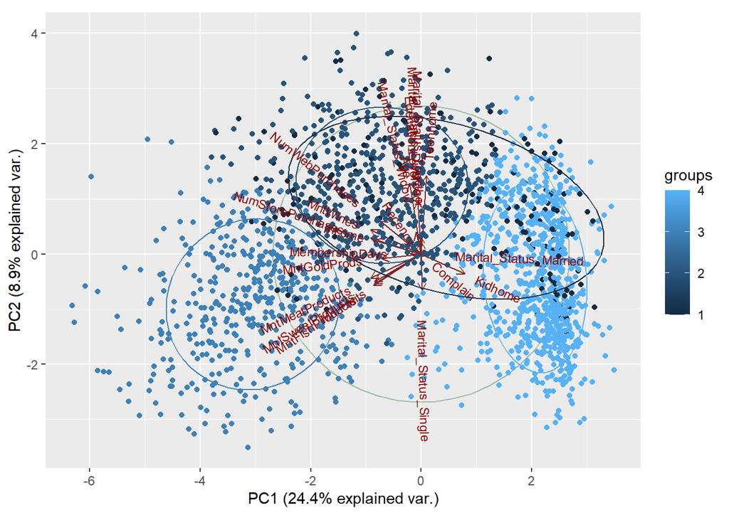

```r
km_out <- kmeans(df_scale, 4)
custom_colors <- c("red", "blue", "green", "black")
ggbiplot(pc_out, groups = km_out$cluster, scale = 0,ellipse = TRUE, circle = TRUE)
```

**Q2.9** Do you see any grouping? Comment on you observation.*(2 points)*

*Answer*… I would see we have 4 grouping considering the above plot

## Characterizing Cluster

**Q2.10** Perform descriptive statistics analysis on obtained cluster. Based on that does one or more group have a distinct characteristics? *(8 points)* Hint: add cluster column to original df dataframe

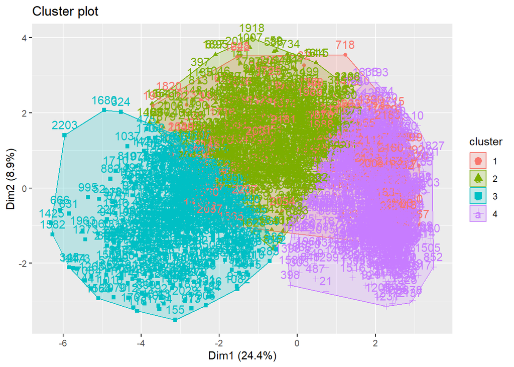

```r
df_market$cluster <- km_out$cluster
cl_summary <- fviz_cluster(km_out, data=df_scale, ellipse = TRUE, ellipse.type = "convex", xlab = NULL,
  ylab = NULL,outlier.color = "black",ggtheme = theme_grey())
cl_summary
```

```r
eu_dist <- dist(df_scale,method='euclidean')
```

## Cluster with Hierarchical Clustering

**Q2.11** Perform clustering with Hierarchical method (Do you need to use scaling here?). Try complete, single and average linkage. Plot dendagram, based on it choose linkage and number of clusters, if possible, explain your choice. *(8 points)*

```r
single<-hclust(eu_dist,method='single')
average<-hclust(eu_dist,method='average')
complete<-hclust(eu_dist,method='complete')
```

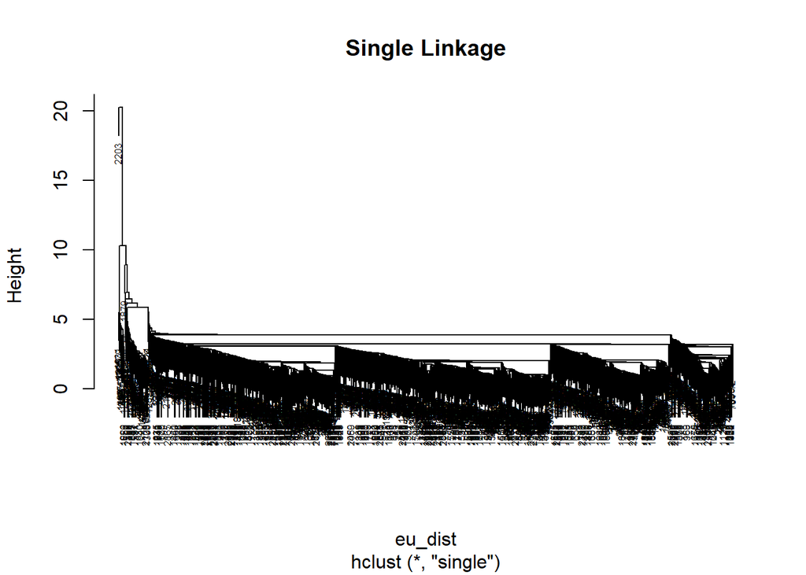

```r
plot(single,main="Single Linkage", cex =  .5)
```

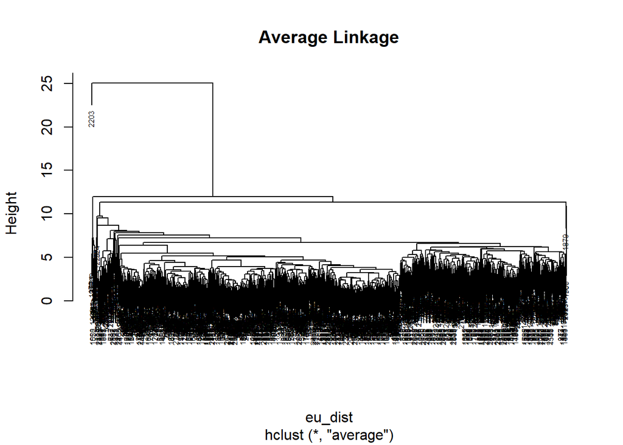

```r
plot(average,main="Average Linkage",cex=.5)
```

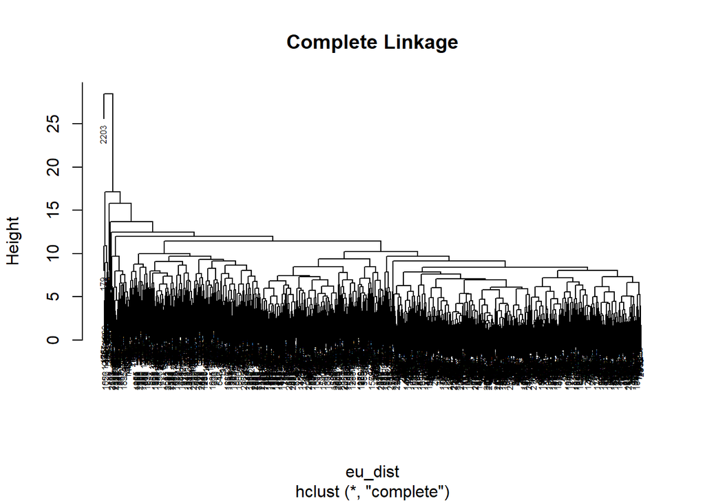

```r
plot(complete,main="Complete Linkage",cex=.5)
```

```r
table(cutree(single, 11))
```

```
##
##    1    2    3    4    5    6    7    8    9   10   11
## 2102    1   76   20    3    1    1    2    1    1    1
```

```r
table(cutree(average,11))
```

```
##
##    1    2    3    4    5    6    7    8    9   10   11
## 2086    4   76   21    1   15    1    1    2    1    1
```

```r
table(cutree(complete,11))
```

```
##
##    1    2    3    4    5    6    7    8    9   10   11
##  541 1054  507    4   76   20    1    2    2    1    1
```

# Additional grading criteria: